# Bioestadística Fundamental

Departamento de Estadística, Sede Bogotá

## Contenido

### Parte I: Transformaciones y GLM

- Respuestas no normales: motivación.
- Selección de una transformación: Box-Cox.
- Modelo lineal generalizado (GLM) como alternativa.

### Parte II: Datos no balanceados

- Motivación y datos proporcionales.
- Métodos aproximados.
- El método exacto: suma de cuadrados tipo III.

### Parte III: ANCOVA

- Descripción del procedimiento y modelo.
- Solución por computador y medias ajustadas.
- Regresión general y factoriales con covariables.

### Parte IV: Medidas repetidas

- Motivación: mediciones no independientes.
- Estructura entre/dentro de sujetos.
- Esfericidad y taller en clase.

Otros Temas de Diseño y Análisis de Experimentos

Transformaciones, datos no balanceados, análisis de covarianza y medidas repetidas: herramientas para situaciones que el ANOVA clásico no resuelve directamente.

## Motivación: cuando la respuesta no es normal

El ANOVA de efectos fijos asume residuos normales con varianza constante. Sin embargo, muchas variables agrícolas **violan estos supuestos de forma natural**:

**Conteos**  
Insectos por planta, plantas enfermas por parcela.

**Proporciones**  
Porcentaje de frutos con daño, germinación.

**Asimetrías**  
Tiempos hasta floración, cargas de plagas.

En estos casos, la varianza suele depender de la media: a mayor conteo promedio, mayor variabilidad. El ANOVA estándar pierde validez.

## Dos caminos posibles

Existen dos estrategias clásicas para abordar respuestas que no cumplen normalidad u homogeneidad de varianza:

Transformar la respuesta

Aplicar una función (raíz, logaritmo, Box-Cox) que estabilice la varianza y aproxime la normalidad, y luego usar el ANOVA habitual.

Modelar directamente

Usar un modelo lineal generalizado (GLM) con la distribución apropiada (Poisson, binomial), sin transformar la escala original.

## El método de Box-Cox: idea general

La **familia de transformaciones potencia de Box-Cox** busca, dentro de una familia parametrizada por $\lambda$, la transformación que hace a los datos más cercanos a la normalidad con varianza homogénea.

Familia de Box-Cox

$$y^{(\lambda)} =
\begin{cases}
\dfrac{y^{\lambda}-1}{\lambda} & \lambda \neq 0 \\[6pt]
\ln(y) & \lambda = 0
\end{cases}$$

$\lambda$ se estima por **máxima verosimilitud**: se elige el valor que maximiza la log-verosimilitud del modelo ANOVA ajustado sobre $y^{(\lambda)}$.

## Valores típicos de $\lambda$

| $\lambda$ | Transformación | Uso típico |
| --- | --- | --- |
| $1$ | Sin transformar | Datos ya aproximadamente normales |
| $0.5$ | Raíz cuadrada $\sqrt{y}$ | Conteos (Poisson) |
| $0$ | Logaritmo $\ln(y)$ | Varianza proporcional a la media al cuadrado |
| $-1$ | Inverso $1/y$ | Tiempos, tasas |

En la práctica se redondea $\hat\lambda$ al valor “interpretable” más cercano dentro de su intervalo de confianza (ej. 0.5 en vez de 0.58).

## Ejemplo agrícola: plagas en algodón

Ejemplo: picudo del algodón, Cesar y Tolima

Un ingeniero agrónomo evalúa 4 dosis de un insecticida biológico (Control, Baja, Media, Alta) sobre el conteo de picudos del algodón por planta. Se muestrean 8 plantas por dosis ($N=32$). La respuesta es un **conteo**, candidato natural a violar normalidad y homogeneidad de varianza.

| Dosis | $n_i$ | $\bar y_i$ (conteo) | $s_i$ |
| --- | --- | --- | --- |
| Control | 8 | 12.38 | 3.07 |
| Dosis baja | 8 | 9.50 | 2.78 |
| Dosis media | 8 | 5.75 | 3.45 |
| Dosis alta | 8 | 3.38 | 1.69 |

## ANOVA sobre el conteo original

Al ajustar el ANOVA directamente sobre el conteo de picudos, se obtiene:

| Fuente | SC | gl | CM | F | valor-p |
| --- | --- | --- | --- | --- | --- |
| Dosis | 381.0 | 3 | 126.9 | 17.50 | $1.4\times10^{-6}$ |
| Error | 203.4 | 28 | 7.26 |  |  |

Shapiro-Wilk en residuos: $W=0.983$, valor-p$=0.877$. Bartlett: $K^2=3.24$, valor-p$=0.356$. En este caso particular ambos supuestos parecen sostenerse, pero la varianza muestral decrece junto con la media ($s_i$ tiende a ser mayor donde $\bar y_i$ es mayor), un patrón típico de datos de conteo que justifica revisar una transformación.

## Gráfico de verosimilitud de Box-Cox

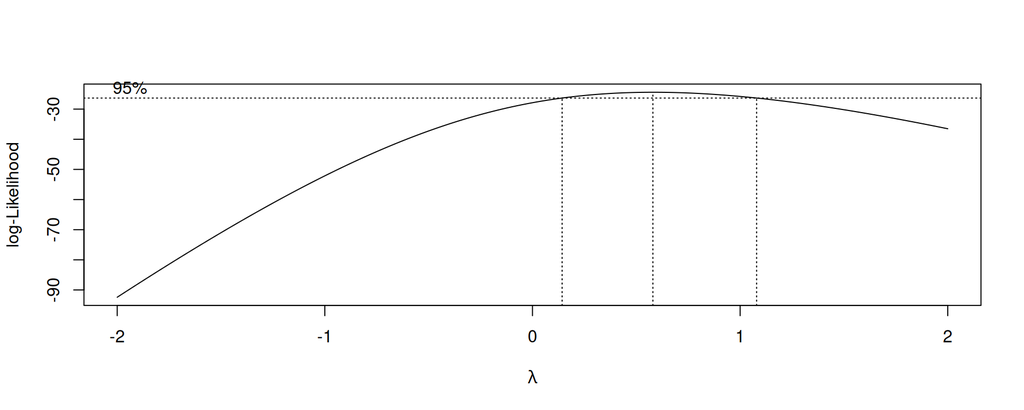

El máximo de la curva se alcanza en $\hat\lambda = 0.58$, con intervalo de confianza al 95% que incluye a $\lambda=0.5$ (raíz cuadrada): se elige $\lambda=0.5$ por su fácil interpretación.

## Re-análisis con la variable transformada

Se aplica $y^{(0.5)}=\sqrt{conteo}$ y se repite el ANOVA:

| Fuente | SC | gl | CM | F | valor-p |
| --- | --- | --- | --- | --- | --- |
| Dosis | 55.2 | 3 | 18.40 | 17.50 | $1.3\times10^{-6}$ |
| Error | 29.4 | 28 | 1.05 |  |  |

## Comparación de conclusiones antes/después

Sin transformar

$F=17.50$, valor-p$=1.4\times10^{-6}$.  
Shapiro $0.877$, Bartlett $0.356$.  
Se rechaza $H_0$.

Transformado ($\sqrt{y}$)

$F=17.50$, valor-p$=1.3\times10^{-6}$.  
Shapiro $0.643$, Bartlett $0.690$.  
Se rechaza $H_0$.

## El modelo lineal generalizado (GLM): motivación

Transformar la respuesta tiene una desventaja: las conclusiones quedan en la escala transformada (ej. “raíz del conteo”), que es difícil de interpretar agronómicamente. El **GLM** evita este problema modelando **directamente** la distribución apropiada de la respuesta.

GLM Poisson para conteos

$$Y_{ij} \sim \text{Poisson}(\mu_{ij}) \qquad \ln(\mu_{ij}) = \mu + \tau_i$$

La función de enlace logarítmica garantiza $\mu_{ij}>0$, y la varianza se modela como $\text{Var}(Y_{ij})=\mu_{ij}$, igual que en la distribución Poisson real.

## GLM Poisson aplicado al ejemplo de plagas

Se ajusta el mismo conjunto de datos con un GLM Poisson y enlace logarítmico:

| Coeficiente | Estimación ($\ln$) | $\exp(\cdot)$: razón vs. Control | valor-p |
| --- | --- | --- | --- |
| Intercepto (Control) | 2.516 | $\mu_{Control}=12.38$ | $<0.001$ |
| Dosis baja | $-0.264$ | 0.768 | 0.083 |
| Dosis media | $-0.766$ | 0.465 | $<0.001$ |
| Dosis alta | $-1.299$ | 0.273 | $<0.001$ |

Prueba de razón de verosimilitudes (deviance) para el efecto de dosis: $\chi^2=51.26$, $gl=3$, valor-p$=4.3\times10^{-11}$.

## Comparación: transformación versus GLM

| Aspecto | Transformación Box-Cox | GLM Poisson |
| --- | --- | --- |
| Escala de interpretación | Transformada ($\sqrt{y}$) | Original (conteo esperado) |
| Varianza modelada | Aproximada vía transformación | Exacta según la distribución |
| Conclusión sobre dosis | Rechaza $H_0$ ($p\approx10^{-6}$) | Rechaza $H_0$ ($p\approx10^{-11}$) |
| Facilidad de uso | Requiere reanálisis ANOVA | Requiere software con GLM |

Ambos enfoques llegan a la misma conclusión sustantiva: las dosis altas reducen significativamente el conteo de plagas. El GLM es preferible cuando se conoce bien la distribución generadora de los datos.

## Errores comunes: transformaciones y GLM

Advertencia: errores frecuentes

- Elegir $\lambda$ “a ojo” sin calcular el intervalo de verosimilitud de Box-Cox.
- Interpretar las medias de la variable transformada como si fueran las medias originales (hay que “destransformar” con cuidado, pues $E[g(Y)] \neq g(E[Y])$).
- Aplicar Box-Cox a datos con ceros o negativos sin un desplazamiento previo.
- Usar GLM Poisson sin verificar sobredispersión (varianza mucho mayor que la media).

Datos no balanceados en diseños factoriales

¿Qué hacer cuando se pierden parcelas, animales o plantas y el diseño factorial deja de ser balanceado?

## Motivación: pérdida de unidades experimentales

En un diseño factorial balanceado, todas las combinaciones de niveles de los factores tienen el **mismo número** de repeticiones $n_{ij}$. En la práctica de campo esto rara vez se mantiene hasta el final del experimento.

Parcelas perdidas por inundación o granizo.

Animales que mueren o se retiran del ensayo.

Plantas que no germinan o se descartan por daño mecánico.

Cuando $n_{ij}$ varía entre celdas, las sumas de cuadrados de los factores principales y la interacción dejan de ser ortogonales: el orden en que se ajustan los términos afecta el resultado.

## Datos proporcionales: el caso fácil

Existe un caso particular de desbalance que permite un análisis exacto y sencillo: cuando el número de observaciones por celda es **proporcional** al producto de los totales marginales.

Condición de proporcionalidad

$$n_{ij} = \frac{n_{i.}\,n_{.j}}{N}$$

Ejemplo conceptual: en un ensayo de 2 variedades de papa $\times$ 3 niveles de riego, si se pierden parcelas pero el patrón resultante sigue siendo proporcional a los totales de fila y columna, las sumas de cuadrados de los efectos principales siguen siendo ortogonales entre sí y se calculan con las fórmulas usuales, simplemente reemplazando $n$ por los $n_{ij}$ observados.

## Métodos aproximados

Cuando el desbalance **no** sigue un patrón proporcional, una alternativa histórica son los **métodos aproximados**, que estiman las celdas faltantes o ponderan las sumas de cuadrados de forma heurística.

**Estimación de valores faltantes:** se “rellena” la celda vacía con un valor que minimiza la suma de cuadrados del error, y se resta un grado de libertad por cada valor estimado.

**Ponderación aproximada:** se usan promedios no ponderados de las medias de celda, ignorando que los $n_{ij}$ difieren, lo cual introduce sesgo.

Ejemplo conceptual: en un ensayo de fertilización de caña con 3 dosis $\times$ 2 variedades, si una combinación pierde 2 de 5 parcelas por una plaga puntual, un método aproximado estimaría el rendimiento faltante a partir de las medias de fila y columna, antes de calcular la tabla ANOVA. Estos métodos son simples pero pueden distorsionar el error tipo I; hoy se prefiere el método exacto.

## El método exacto: sumas de cuadrados tipo III

El método moderno y exacto consiste en plantear el diseño factorial como un **modelo de regresión general** con variables indicadoras, y calcular la suma de cuadrados de **tipo III**: la contribución de cada efecto controlando por todos los demás efectos del modelo.

Suma de cuadrados tipo III

$$SC_{III}(\text{efecto}) = SCE(\text{modelo sin el efecto}) - SCE(\text{modelo completo})$$

A diferencia de la suma de cuadrados tipo I (secuencial), el tipo III no depende del orden en que se listan los factores en el modelo: cada efecto se ajusta “al último”, después de los demás.

## Ejemplo agrícola: frijol desbalanceado

Ejemplo: variedad $\times$ fertilizante en frijol, Boyacá

Se evalúan 2 variedades de frijol (Diacol, ICA) y 2 niveles de fertilizante (Bajo, Alto) en un diseño $2\times2$. Por pérdida de parcelas durante el ciclo, el número de repeticiones por combinación quedó desbalanceado. Respuesta: rendimiento (t/ha).

|  | Fertilizante Bajo | Fertilizante Alto |
| --- | --- | --- |
| Diacol | $n=5$, $\bar y=1.78$ | $n=7$, $\bar y=2.35$ |
| ICA | $n=6$, $\bar y=2.01$ | $n=4$, $\bar y=2.97$ |

$N=22$ parcelas en total (no 24, como en un diseño $2\times2$ balanceado con $n=6$). Los $n_{ij}$ no siguen un patrón proporcional: $\frac{12\times11}{22}=6\neq5$.

## Tabla ANOVA tipo III: frijol

Al ajustar el modelo $rend = \mu + variedad + fert + variedad{:}fert + \varepsilon$ y calcular sumas de cuadrados tipo III:

| Fuente | SC (tipo III) | gl | F | valor-p |
| --- | --- | --- | --- | --- |
| Variedad | 0.93 | 1 | 13.39 | 0.0018 |
| Fertilizante | 3.11 | 1 | 44.61 | $<0.0001$ |
| Variedad $\times$ Fertilizante | 0.20 | 1 | 2.86 | 0.108 |
| Error | 1.26 | 18 |  |  |

Si se calculan sumas de cuadrados tipo I cambiando el orden de los factores, las SC de Variedad y Fertilizante cambian (0.42 y 2.99 en un orden, 0.91 y 2.50 en el otro); la SC tipo III es la única invariante al orden.

## Conclusión del ejemplo de frijol

Efectos principales

Tanto la variedad ($p=0.0018$) como el fertilizante ($p<0.0001$) afectan significativamente el rendimiento.

Interacción

No es significativa ($p=0.108$): el efecto del fertilizante es similar en ambas variedades.

Conclusión agronómica: la variedad ICA con fertilización alta presenta el mayor rendimiento promedio (2.97 t/ha); el desbalance en las repeticiones no impidió un análisis válido gracias al método exacto (tipo III).

## Errores comunes: datos no balanceados

Advertencia: errores frecuentes

- Usar sumas de cuadrados tipo I (secuenciales) en datos desbalanceados sin justificar el orden de los factores.
- Eliminar parcelas adicionales para “forzar” el balance, perdiendo información valiosa.
- Ignorar que un desbalance severo reduce la potencia para detectar la interacción.
- Confundir el caso de datos proporcionales (análisis exacto sencillo) con el caso general, que requiere el método de regresión tipo III.

Análisis de Covarianza (ANCOVA)

¿Cómo ajustar la comparación de tratamientos cuando existe una variable continua, no controlable experimentalmente, que afecta la respuesta?

## Descripción del procedimiento: motivación

En muchos experimentos agrícolas, las unidades experimentales no parten de condiciones idénticas: las plántulas tienen tamaños distintos antes de aplicar el tratamiento, los animales pesan diferente al inicio, los suelos tienen distinta fertilidad basal.

El **Análisis de Covarianza (ANCOVA)** combina el ANOVA con la regresión: ajusta la respuesta por una variable continua (la **covariable**) medida **antes** del tratamiento, que no se puede controlar experimentalmente pero sí estadísticamente.

Resultado: comparaciones de tratamiento más precisas, con menor varianza del error, al remover la variabilidad explicada por la covariable.

## El modelo de ANCOVA

Modelo de Análisis de Covarianza

$$y_{ij} = \mu + \tau_i + \beta\,(x_{ij}-\bar x_{..}) + \varepsilon_{ij}$$

- $y_{ij}$: respuesta del sujeto $j$ en el tratamiento $i$ (ej. altura final).
- $x_{ij}$: covariable del mismo sujeto, medida antes del tratamiento (ej. altura inicial).
- $\beta$: pendiente común de regresión entre $y$ y $x$, igual para todos los tratamientos (supuesto de homogeneidad de pendientes).
- $\tau_i$: efecto del tratamiento $i$, **ya ajustado** por la covariable.
- $\varepsilon_{ij}\sim N(0,\sigma^2)$ independientes.

## Ejemplo agrícola: eucalipto y altura inicial

Ejemplo: plántulas de eucalipto, vivero forestal

Se comparan 3 tratamientos de fertilización (Testigo, Orgánico, Químico) sobre el crecimiento de plántulas de eucalipto, midiendo la **altura final** (cm) a los 6 meses. Como las plántulas no partían exactamente de la misma altura, se registra la **altura inicial** (cm) como covariable. $n=10$ plántulas por tratamiento, $N=30$.

| Tratamiento | $\bar x_i$ (altura inicial) | $\bar y_i$ (altura final, sin ajustar) |
| --- | --- | --- |
| Testigo | 34.66 | 40.09 |
| Orgánico | 34.16 | 54.51 |
| Químico | 36.73 | 64.98 |

## ANOVA simple versus ANCOVA: por qué ajustar

Si se ignora la covariable y se ajusta un ANOVA simple sobre la altura final:

| Fuente | SC | gl | CM | F | valor-p |
| --- | --- | --- | --- | --- | --- |
| Tratamiento | 3124 | 2 | 1562 | 46.0 | $2\times10^{-9}$ |
| Error | 917 | 27 | 34.0 |  |  |

Aunque las alturas iniciales son parecidas entre tratamientos (34.16 a 36.73 cm), parte del error de 917 todavía contiene variabilidad explicable por esas pequeñas diferencias iniciales. El ANCOVA remueve esa fuente de ruido.

## Tabla ANCOVA: eucalipto

Ajustando el modelo $altura\_final = \mu + \beta(altura\_inicial-\bar x) + \tau_i$:

| Fuente | SC (tipo III) | gl | CM | F | valor-p |
| --- | --- | --- | --- | --- | --- |
| Covariable (altura inicial) | 680.2 | 1 | 680.2 | 74.71 | $4.0\times10^{-9}$ |
| Tratamiento (ajustado) | 2541.9 | 2 | 1270.9 | 139.6 | $1.2\times10^{-14}$ |
| Error | 236.7 | 26 | 9.10 |  |  |

$CM_E$ bajó de $34.0$ (ANOVA simple) a $9.10$ (ANCOVA): la covariable explicó una parte sustancial del error, lo que aumentó drásticamente la potencia de la prueba sobre tratamiento ($F$ pasó de 46.0 a 139.6).

## Pendiente común y homogeneidad de pendientes

El modelo ANCOVA asume una **pendiente común** $\beta$ entre la covariable y la respuesta, igual en los tres tratamientos. Este supuesto se verifica probando la interacción covariable $\times$ tratamiento.

$\hat\beta = 1.184$ cm de altura final por cada cm adicional de altura inicial (centrada).

Prueba de interacción altura_inicial $\times$ tratamiento: $F=0.08$, $gl=(2,24)$, valor-p$=0.92$. No hay evidencia de que las pendientes difieran entre tratamientos: el supuesto se cumple.

## Medias ajustadas

Las **medias ajustadas** estiman cuál sería la altura final promedio de cada tratamiento si todas las plántulas hubieran partido de la misma altura inicial (la media general $\bar x_{..}=35.18$ cm):

Fórmula de la media ajustada

$$\bar y_{i,\text{aj}} = \bar y_{i.} - \hat\beta\,(\bar x_{i.}-\bar x_{..})$$

| Tratamiento | $\bar y_i$ (sin ajustar) | $\bar y_{i,\text{aj}}$ (ajustada) |
| --- | --- | --- |
| Testigo | 40.09 | 40.71 |
| Orgánico | 54.51 | 55.72 |
| Químico | 64.98 | 63.15 |

## Gráfico de las rectas de regresión por tratamiento

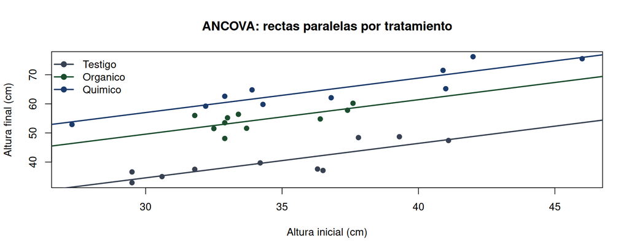

Las tres rectas son paralelas (pendiente común $\hat\beta=1.184$): el ANCOVA simplemente desplaza verticalmente cada tratamiento.

## Solución por computador: cómo interpretar la salida

Cualquier software estadístico (R, SAS, Minitab, SPSS) reporta el ANCOVA con esta estructura. Es clave identificar cada columna:

| Columna | Significado |
| --- | --- |
| Fila “covariable” | Prueba si $\beta\neq0$: ¿la covariable realmente influye en $Y$? |
| Fila “tratamiento” | Prueba $H_0:\tau_1=\cdots=\tau_a=0$, **ya controlando** por la covariable |
| Coeficiente de la covariable | Estimación de $\hat\beta$, la pendiente común |
| Medias ajustadas / “LS Means” | Medias de tratamiento corregidas por la covariable |

El orden recomendado de lectura es: (1) verificar homogeneidad de pendientes, (2) revisar significancia de la covariable, (3) interpretar el efecto de tratamiento ajustado, (4) comparar medias ajustadas.

## Desarrollo mediante regresión general

Igual que en clases anteriores, el ANCOVA puede verse como una **prueba de significancia de regresión general**: se compara un modelo completo contra modelos reducidos.

| Modelo | SC residual (SCE) | gl |
| --- | --- | --- |
| Reducido: solo covariable $y=\mu+\beta x+\varepsilon$ | 2778.7 | 28 |
| Completo: covariable + tratamiento | 236.7 | 26 |

$$F=\frac{(2778.7-236.7)/2}{236.7/26}=139.6$$
Idéntico al estadístico $F$ de tratamiento en la tabla ANCOVA: el efecto de tratamiento es la diferencia entre incluir o no las variables indicadoras, controlando ya por la covariable.

## Experimentos factoriales con covariables

El ANCOVA se extiende de forma natural a **más de un factor**: el modelo simplemente agrega los efectos principales y la interacción, manteniendo el ajuste por la covariable.

ANCOVA factorial

$$y_{ijk} = \mu + \alpha_i + \gamma_j + (\alpha\gamma)_{ij} + \beta\,(x_{ijk}-\bar x_{...}) + \varepsilon_{ijk}$$

Ejemplo conceptual: en el ensayo de eucalipto, si además se cruzan los 3 tratamientos de fertilización con 2 tipos de sustrato (arenoso, franco), el ANCOVA factorial evaluaría los efectos de fertilización, sustrato y su interacción, todos ajustados por la altura inicial de cada plántula.

## Errores comunes: ANCOVA

Advertencia: errores frecuentes

- Usar como covariable una variable medida **después** del tratamiento (puede estar afectada por él, violando el supuesto de independencia entre covariable y tratamiento).
- Omitir la verificación de homogeneidad de pendientes: si las pendientes difieren entre tratamientos, el modelo de pendiente común no es válido.
- Interpretar las medias **sin ajustar** cuando los tratamientos partieron de niveles distintos de la covariable.
- Aplicar ANCOVA cuando la covariable ya está perfectamente balanceada entre tratamientos (en ese caso, el ANOVA simple es suficiente y más sencillo).

Medidas Repetidas

¿Cómo analizar correctamente una variable medida varias veces en la misma unidad experimental a lo largo del tiempo?

## Motivación: mediciones repetidas en el tiempo

En muchos experimentos agrícolas y forestales se mide la **misma unidad experimental varias veces**: la altura de una plántula cada mes, el peso de un animal cada semana, el rendimiento de una parcela cada cosecha.

Ejemplo: la altura de plántulas de eucalipto se mide cada mes durante 6 meses, bajo dos regímenes de riego (con riego, sin riego).

Problema: las 6 mediciones de una misma plántula **no son independientes** entre sí (una plántula alta en el mes 1 probablemente sigue siendo alta en el mes 2). Tratar el tiempo como un factor más de un ANOVA factorial viola el supuesto de independencia.

## Por qué no es un ANOVA factorial simple

ANOVA factorial común

Asume que todas las observaciones, dentro y entre niveles de cualquier factor, son independientes entre sí.

Medidas repetidas

Las observaciones del **mismo sujeto** en distintos tiempos están correlacionadas; se requiere un modelo que reconozca esa estructura.

Ignorar la correlación intra-sujeto subestima el error estándar de los efectos de tiempo, inflando artificialmente la significancia estadística.

## Estructura entre sujetos y dentro de sujetos

Un diseño de medidas repetidas distingue dos tipos de factores:

Factor entre sujetos (between-subjects)

El **tratamiento** (riego / sin riego): cada plántula recibe solo uno de los niveles, de forma permanente.

Factor dentro de sujetos (within-subjects)

El **tiempo** (mes 1 a mes 6): cada plántula pasa por **todos** los niveles de este factor.

## Ejemplo agrícola completo: crecimiento de eucalipto

Ejemplo: altura de eucalipto bajo riego, vivero forestal

Se siguen 16 plántulas de eucalipto (8 con riego suplementario, 8 sin riego) y se mide su altura (cm) cada mes durante 6 meses.

| Tratamiento | Mes 1 | Mes 2 | Mes 3 | Mes 4 | Mes 5 | Mes 6 |
| --- | --- | --- | --- | --- | --- | --- |
| Riego | 20.39 | 26.78 | 35.26 | 44.54 | 54.16 | 64.70 |
| Sin riego | 19.66 | 23.86 | 28.74 | 33.50 | 38.60 | 43.36 |

Valores: medias de altura (cm) por tratamiento y mes, sobre 8 plántulas cada uno.

## Gráfico de perfiles de crecimiento

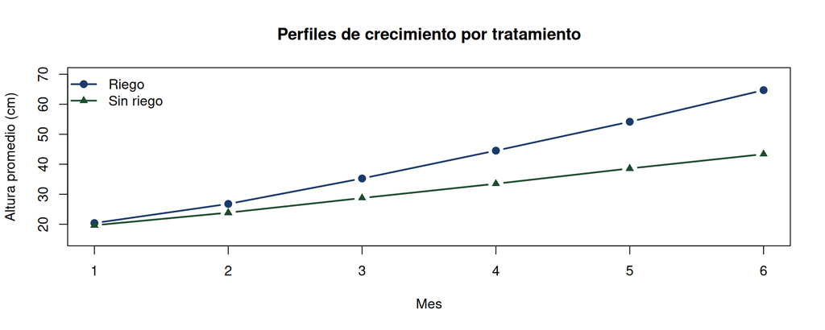

Los perfiles no son paralelos: la brecha entre tratamientos crece con el tiempo, lo que sugiere una **interacción tratamiento $\times$ tiempo**.

## Tabla de análisis de medidas repetidas

El análisis separa la variabilidad **entre sujetos** (tratamiento) de la variabilidad **dentro de sujetos** (tiempo e interacción):

[output not shown]

La interacción tratamiento $\times$ mes es altamente significativa: confirma lo observado en el gráfico de perfiles: el riego acelera el crecimiento de forma creciente en el tiempo.

## Corrección por esfericidad: idea general

La tabla anterior asume **esfericidad**: que las varianzas de las diferencias entre cualquier par de tiempos son iguales. Esta condición rara vez se cumple exactamente con datos de crecimiento.

La prueba de **esfericidad de Mauchly** contrasta $H_0:$ se cumple la esfericidad. En este ejemplo: estadístico $=0.261$, valor-p$=0.308$ — no se rechaza, por lo que la corrección no es estrictamente necesaria.

Cuando la esfericidad falla, se aplican **correcciones** que reducen los grados de libertad del estadístico $F$ (Greenhouse-Geisser, Huynh-Feldt), haciendo la prueba más conservadora sin tener que abandonar el ANOVA de medidas repetidas.

## Conclusión del ejemplo de eucalipto

Resultado estadístico

Efectos significativos de tratamiento, tiempo, y su interacción (todos $p<0.0001$). Esfericidad razonable ($p=0.308$).

Conclusión agronómica

El riego suplementario no solo aumenta la altura final, sino que **acelera la tasa de crecimiento** mes a mes, ampliando la diferencia con el tiempo.

## Errores comunes: medidas repetidas

Advertencia: errores frecuentes

- Analizar el factor tiempo como si fuera independiente entre mediciones (ANOVA factorial estándar), ignorando la correlación intra-sujeto.
- Ignorar la prueba de esfericidad y reportar el valor-p sin corrección cuando la esfericidad falla claramente.
- Confundir el factor “entre sujetos” (tratamiento, fijo por sujeto) con el factor “dentro de sujetos” (tiempo, varía dentro del mismo sujeto).
- No graficar los perfiles de evolución temporal antes del análisis formal: el gráfico revela visualmente si existe interacción tratamiento $\times$ tiempo.

## Resumen general de la clase

| Tema | Problema que resuelve | Herramienta |
| --- | --- | --- |
| Box-Cox / GLM | Respuesta no normal o varianza heterogénea | Transformación potencia o modelo Poisson/binomial |
| Datos no balanceados | Pérdida de parcelas en diseño factorial | Suma de cuadrados tipo III (regresión general) |
| ANCOVA | Diferencias iniciales no controlables | Ajuste por covariable continua |
| Medidas repetidas | Mediciones correlacionadas en el tiempo | Factores entre/dentro de sujetos, esfericidad |

## Taller en Clase

## Instrucciones

Para cada ejercicio:

1. Identifique el tema involucrado (transformación, GLM, datos no balanceados, ANCOVA o medidas repetidas).
2. Plantee el modelo o las hipótesis correspondientes.
3. Realice los cálculos solicitados con la información suministrada.
4. Aplique el criterio de decisión indicado.
5. Redacte una conclusión en el contexto agrícola del problema.

## Ejercicio 1

Problema: transformación de datos de conteo

En un cultivo de arroz en el Tolima, se cuenta el número de plantas afectadas por el hongo *Pyricularia* por parcela, bajo 3 tratamientos fungicidas. Un análisis de Box-Cox sobre los datos arroja $\hat\lambda=0.1$, con intervalo de confianza del 95% que incluye a $\lambda=0$.

1. ¿Qué transformación recomienda aplicar? (b) Justifique por qué el GLM Poisson sería una alternativa razonable a la transformación.

## Ejercicio 2

Problema: datos no balanceados

Un ensayo factorial $2\times2$ de variedad de café (Caturra, Castillo) $\times$ sombra (Con sombra, Sin sombra) perdió parcelas por una helada. Quedaron: Caturra-Con sombra ($n=8$), Caturra-Sin sombra ($n=5$), Castillo-Con sombra ($n=6$), Castillo-Sin sombra ($n=9$).

1. Verifique si el patrón de $n_{ij}$ es proporcional. (b) Indique qué método de análisis (proporcional, aproximado o exacto tipo III) es apropiado y por qué.

## Ejercicio 3

Problema: ANCOVA en ganadería

Se comparan 2 dietas de ceba en novillos de los Llanos, ajustando por el peso inicial (covariable). Con $\bar y_1=420$ kg, $\bar y_2=455$ kg (pesos finales sin ajustar), $\bar x_1=310$ kg, $\bar x_2=325$ kg, $\bar x_{..}=317.5$ kg y $\hat\beta=1.05$.

Calcule las medias ajustadas $\bar y_{1,\text{aj}}$ y $\bar y_{2,\text{aj}}$ e interprete si la diferencia entre dietas cambia tras el ajuste.

## Ejercicio 4

Problema: ANCOVA, prueba de regresión general

En un ensayo de fertilización de caña ajustado por covariable (contenido inicial de materia orgánica del suelo), el modelo reducido (solo covariable) tiene $SCE=850$ con $gl=22$; el modelo completo (covariable + tratamiento, 3 niveles) tiene $SCE=410$ con $gl=20$.

Calcule el estadístico $F$ para el efecto de tratamiento y compárelo con $F_{0.05,2,20}=3.49$. Concluya.

## Ejercicio 5

Problema: medidas repetidas en floricultura

En un cultivo de rosas en Cundinamarca, se mide el número de botones florales por planta cada semana durante 4 semanas, en 2 tratamientos de fertirriego (Estándar, Mejorado), con 10 plantas por tratamiento. El ANOVA de medidas repetidas reporta: tratamiento $F=22.4$ ($gl=1,18$), semana $F=58.1$ ($gl=3,54$), interacción tratamiento$\times$semana $F=9.7$ ($gl=3,54$), todos con valor-p$<0.01$.

1. Interprete cada uno de los tres efectos. (b) Explique por qué no sería correcto analizar estos datos con un ANOVA factorial de 2 factores independientes.